# Анализ бизнес-показателей приложения Procrastinate Pro+

Развлекательное приложение Procrastinate Pro+ последние несколько месяцев терпит убытки, несмотря на огромные вложения в рекламу.

**Задача** - разобраться в причинах и помочь компании выйти в плюс.

Есть данные о пользователях, привлечённых с 1 мая по 27 октября 2019 года:

- лог сервера с данными об их посещениях,
- выгрузка их покупок за этот период,
- рекламные расходы.

**Цель проекта**

На основе предоставленных данных необходимо изучить:

- откуда приходят пользователи и какими устройствами они пользуются,
- сколько стоит привлечение пользователей из различных рекламных каналов;
- сколько денег приносит каждый клиент,
- когда расходы на привлечение клиента окупаются,
- какие факторы мешают привлечению клиентов.

**Ход исследования**

**Шаг 1. Загрузить данные и подготовить их к анализу.**

- Загрузить данные о визитах, заказах и рекламных расходах из CSV-файлов в переменные.
- Изучить данные и выполнить предобработку.

**Шаг 2. Задать функции для расчёта и анализа LTV, ROI, удержания и конверсии.**

**Шаг 3. Исследовательский анализ данных.**

- Составить профили пользователей. Определить минимальную и максимальную даты привлечения пользователей.
- Выяснить, из каких стран пользователи приходят в приложение и на какую страну приходится больше всего платящих пользователей. Построить таблицу, отражающую количество пользователей и долю платящих из каждой страны.
- Узнать, какими устройствами пользуются клиенты и какие устройства предпочитают платящие пользователи. Построить таблицу, отражающую количество пользователей и долю платящих для каждого устройства.
- Изучить рекламные источники привлечения и определите каналы, из которых пришло больше всего платящих пользователей. Построить таблицу, отражающую количество пользователей и долю платящих для каждого канала привлечения.

**Шаг 4. Маркетинг.**

- Посчитать общую сумму расходов на маркетинг.
- Выяснить, как траты распределены по рекламным источникам, то есть сколько денег потратили на каждый источник.
- Построить график с визуализацией динамики изменения расходов во времени по неделям по каждому источнику. Затем на другом графике визуализируйте динамику изменения расходов во времени по месяцам по каждому источнику.
- Узнать, сколько в среднем стоило привлечение одного пользователя (CAC) из каждого источника. Использовать профили пользователей.

**Шаг 5. Оценить окупаемость рекламы.**

- Проанализировать окупаемость рекламы c помощью графиков LTV и ROI, а также графики динамики LTV, CAC и ROI.
- Проверить конверсию пользователей и динамику её изменения. То же самое сделать с удержанием пользователей. Построить и изучить графики конверсии и удержания.
- Проанализировать окупаемость рекламы с разбивкой по устройствам. Построить графики LTV и ROI, а также графики динамики LTV, CAC и ROI.
- Проанализировать окупаемость рекламы с разбивкой по странам. Построить графики LTV и ROI, а также графики динамики LTV, CAC и ROI.
- Проанализировать окупаемость рекламы с разбивкой по рекламным каналам. Построить графики LTV и ROI, а также графики динамики LTV, CAC и ROI.
- Ответить на такие вопросы:
1. Окупается ли реклама, направленная на привлечение пользователей в целом?
2. Какие устройства, страны и рекламные каналы могут оказывать негативное влияние на окупаемость рекламы?
3. Чем могут быть вызваны проблемы окупаемости?

**Шаг 6. Написать выводы.**

- Выделить причины неэффективности привлечения пользователей.
- Сформулировать рекомендации для отдела маркетинга.

## Содержание проекта

- **Загрузка и обзор данных**
- **Предобработка данных**
- - Итоги предобработки данных
- **Функции для вычисления метрик и построения графиков**
- **Исследовательский анализ данных**
- - Составление пользовательских профилей
- - Страны и пользователи
- - Устройства и пользователи
- - Каналы привлечения и пользователи
- - Выводы
- **Маркетинг**
- - Общая сумма расходов на маркетинг
- - Распределение трат по рекламным источникам
- - Динамика изменения расходов во времени по неделям (по месяцам) по каждому источнику
- - Средняя стоимость привлечения одного пользователя из каждого источника
- - Выводы
- **Оценка окупаемости рекламы**
- - Окупаемость рекламы. LTV, ROY, CAC
- - Окупаемость рекламы с разбивкой по устройствам
- - Окупаемость рекламы с разбивкой по странам
- - Окупаемость рекламы с разбивкой по рекламным каналам
- - Выводы
- **Связь рекламных каналов и регионов**
- **Общий вывод**

## Загрузка и общий обзор данных

```python
# импортируем библиотеки
import pandas as pd
import numpy as np
from datetime import datetime, timedelta
from matplotlib import pyplot as plt
import seaborn as sns
import missingno as msno
```

```python
#функция для вывода общей информации
def genetal_info(data):
     return print('Первые 10 строк датафрейма:'), \
    display(data.head(10)), \
    print('Информация о датафрейме:'), \
    display(data.info()), \
    print('Размер датафрейма:'), \
    display(data.shape), \
    print('Название столбцов:'), \
    display(data.columns), \
    print('Процент пропущенных значений:'), \
    display(pd.DataFrame(data.isna().mean()*100).style.set_precision(1).background_gradient('coolwarm')), \
    print('Визуализация пропусков:'), \
    display(msno.matrix(data, labels=True))
```

```python
# загрузка данных
visits, orders, costs = (
        pd.read_csv('datasets/visits_info_short.csv'),
        pd.read_csv('datasets/orders_info_short.csv'),
        pd.read_csv('datasets/costs_info_short.csv')
)
```

```
Первые 10 строк датафрейма:
```

|  | User Id | Region | Device | Channel | Session Start | Session End |
| --- | --- | --- | --- | --- | --- | --- |
| 0 | 981449118918 | United States | iPhone | organic | 2019-05-01 02:36:01 | 2019-05-01 02:45:01 |
| 1 | 278965908054 | United States | iPhone | organic | 2019-05-01 04:46:31 | 2019-05-01 04:47:35 |
| 2 | 590706206550 | United States | Mac | organic | 2019-05-01 14:09:25 | 2019-05-01 15:32:08 |
| 3 | 326433527971 | United States | Android | TipTop | 2019-05-01 00:29:59 | 2019-05-01 00:54:25 |
| 4 | 349773784594 | United States | Mac | organic | 2019-05-01 03:33:35 | 2019-05-01 03:57:40 |
| 5 | 90242400005 | United States | iPhone | RocketSuperAds | 2019-05-01 07:14:52 | 2019-05-01 08:19:56 |
| 6 | 43958116050 | United States | Android | organic | 2019-05-01 09:03:21 | 2019-05-01 10:08:39 |
| 7 | 185365244969 | United States | iPhone | organic | 2019-05-01 09:37:03 | 2019-05-01 10:00:43 |
| 8 | 446013509831 | United States | iPhone | RocketSuperAds | 2019-05-01 10:26:00 | 2019-05-01 10:59:17 |
| 9 | 100970711362 | United States | Mac | TipTop | 2019-05-01 04:39:53 | 2019-05-01 04:57:05 |

```
Информация о датафрейме:
<class 'pandas.core.frame.DataFrame'>
RangeIndex: 309901 entries, 0 to 309900
Data columns (total 6 columns):
 #   Column         Non-Null Count   Dtype
---  ------         --------------   -----
 0   User Id        309901 non-null  int64
 1   Region         309901 non-null  object
 2   Device         309901 non-null  object
 3   Channel        309901 non-null  object
 4   Session Start  309901 non-null  object
 5   Session End    309901 non-null  object
dtypes: int64(1), object(5)
memory usage: 14.2+ MB
```

```
None
```

```
Размер датафрейма:
```

```
(309901, 6)
```

```
Название столбцов:
```

```
Index(['User Id', 'Region', 'Device', 'Channel', 'Session Start',
       'Session End'],
      dtype='object')
```

```
Процент пропущенных значений:
```

|  | 0 |
| --- | --- |
| User Id | 0.0 |
| Region | 0.0 |
| Device | 0.0 |
| Channel | 0.0 |
| Session Start | 0.0 |
| Session End | 0.0 |

```
Визуализация пропусков:
```

```
(None, None, None, None, None, None, None, None, None, None, None, None)
```

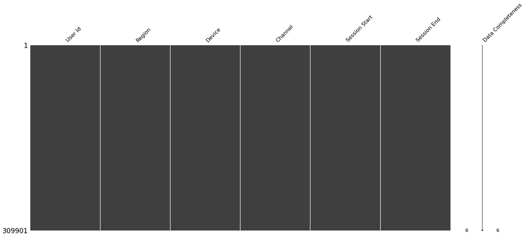

```python
# общая информация о датасете visits
genetal_info(visits)
```

**При обзоре датасета visits:**

- не обнаружено пропущенных значений
- обнаружены некорректные названия всех столбцов. Их нужно привести к snake_case.
- обнаружен некорректный тип данных значений в столбцах с датой и временем `Session Start` и `Session End` - object. Нужно преобразовать их в datetime.

```
Первые 10 строк датафрейма:
```

|  | User Id | Event Dt | Revenue |
| --- | --- | --- | --- |
| 0 | 188246423999 | 2019-05-01 23:09:52 | 4.99 |
| 1 | 174361394180 | 2019-05-01 12:24:04 | 4.99 |
| 2 | 529610067795 | 2019-05-01 11:34:04 | 4.99 |
| 3 | 319939546352 | 2019-05-01 15:34:40 | 4.99 |
| 4 | 366000285810 | 2019-05-01 13:59:51 | 4.99 |
| 5 | 129100331057 | 2019-05-01 01:56:28 | 4.99 |
| 6 | 626807144131 | 2019-05-01 02:39:21 | 4.99 |
| 7 | 914062168985 | 2019-05-01 02:02:18 | 4.99 |
| 8 | 769669137453 | 2019-05-01 03:39:47 | 4.99 |
| 9 | 434198630691 | 2019-05-01 18:16:50 | 5.99 |

```
Информация о датафрейме:
<class 'pandas.core.frame.DataFrame'>
RangeIndex: 40212 entries, 0 to 40211
Data columns (total 3 columns):
 #   Column    Non-Null Count  Dtype
---  ------    --------------  -----
 0   User Id   40212 non-null  int64
 1   Event Dt  40212 non-null  object
 2   Revenue   40212 non-null  float64
dtypes: float64(1), int64(1), object(1)
memory usage: 942.6+ KB
```

```
None
```

```
Размер датафрейма:
```

```
(40212, 3)
```

```
Название столбцов:
```

```
Index(['User Id', 'Event Dt', 'Revenue'], dtype='object')
```

```
Процент пропущенных значений:
```

|  | 0 |
| --- | --- |
| User Id | 0.0 |
| Event Dt | 0.0 |
| Revenue | 0.0 |

```
Визуализация пропусков:
```

```
(None, None, None, None, None, None, None, None, None, None, None, None)
```

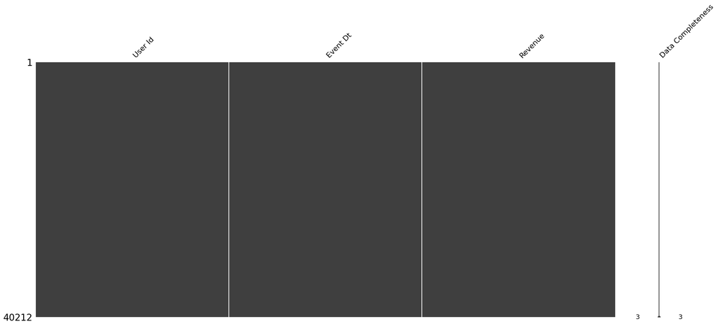

```python
#общая информация о датасете orders
genetal_info(orders)
```

**При обзоре датасета orders:**

- не обнаружено пропущенных значений
- обнаружены некорректные названия всех столбцов. Их нужно привести к snake_case.
- обнаружен некорректный тип данных значений в столбцe с датой и временем `Event Dt` - object. Нужно преобразовать его в datetime.

```
Первые 10 строк датафрейма:
```

|  | dt | Channel | costs |
| --- | --- | --- | --- |
| 0 | 2019-05-01 | FaceBoom | 113.3 |
| 1 | 2019-05-02 | FaceBoom | 78.1 |
| 2 | 2019-05-03 | FaceBoom | 85.8 |
| 3 | 2019-05-04 | FaceBoom | 136.4 |
| 4 | 2019-05-05 | FaceBoom | 122.1 |
| 5 | 2019-05-06 | FaceBoom | 118.8 |
| 6 | 2019-05-07 | FaceBoom | 101.2 |
| 7 | 2019-05-08 | FaceBoom | 100.1 |
| 8 | 2019-05-09 | FaceBoom | 93.5 |
| 9 | 2019-05-10 | FaceBoom | 104.5 |

```
Информация о датафрейме:
<class 'pandas.core.frame.DataFrame'>
RangeIndex: 1800 entries, 0 to 1799
Data columns (total 3 columns):
 #   Column   Non-Null Count  Dtype
---  ------   --------------  -----
 0   dt       1800 non-null   object
 1   Channel  1800 non-null   object
 2   costs    1800 non-null   float64
dtypes: float64(1), object(2)
memory usage: 42.3+ KB
```

```
None
```

```
Размер датафрейма:
```

```
(1800, 3)
```

```
Название столбцов:
```

```
Index(['dt', 'Channel', 'costs'], dtype='object')
```

```
Процент пропущенных значений:
```

|  | 0 |
| --- | --- |
| dt | 0.0 |
| Channel | 0.0 |
| costs | 0.0 |

```
Визуализация пропусков:
```

```
(None, None, None, None, None, None, None, None, None, None, None, None)
```

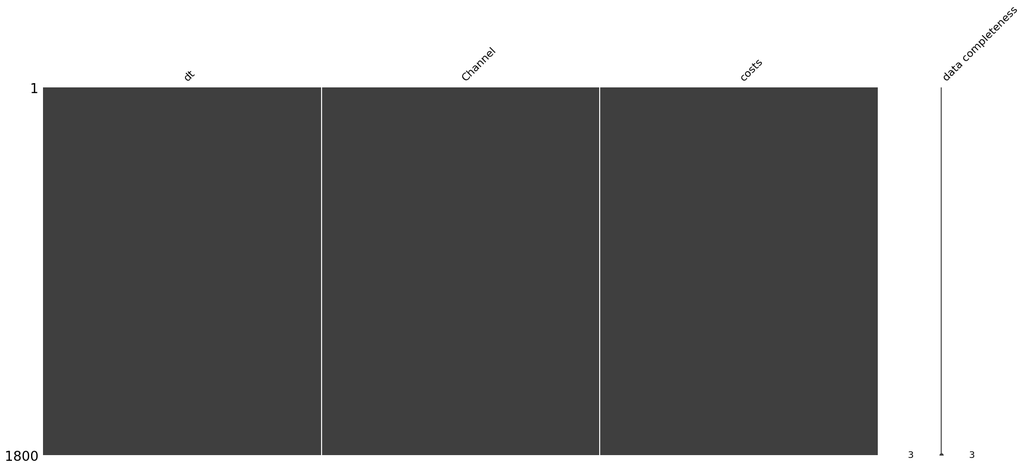

```python
#общая информация о датасете costs
genetal_info(costs)
```

**При обзоре датасета costs:**

- не обнаружено пропущенных значений
- обнаружены некорректнное название столбцa `Channel`. Его нужно привести к snake_case.
- обнаружен некорректный тип данных значений в столбцe с датой и временем `dt` - object. Нужно преобразовать его в datetime.

## Предобработка данных

```python
# приведем назавания столбцов к snake_case
def col_snake(data):
    data.columns = [nm.lower().replace(' ', '_') for nm in data.columns]
    return data
```

```python
visits= col_snake(visits)
orders= col_snake(orders)
costs= col_snake(costs)
```

```python
display(visits.columns)
display(orders.columns)
display(costs.columns)
```

```
Index(['user_id', 'region', 'device', 'channel', 'session_start',
       'session_end'],
      dtype='object')
```

```
Index(['user_id', 'event_dt', 'revenue'], dtype='object')
```

```
Index(['dt', 'channel', 'costs'], dtype='object')
```

```python
#изменим типы данных в столбцах с датой и временем
visits['session_start'] = pd.to_datetime(visits['session_start'])
visits['session_end'] = pd.to_datetime(visits['session_end'])
orders['event_dt'] = pd.to_datetime(orders['event_dt'])
costs['dt'] = pd.to_datetime(costs['dt']).dt.date
```

```python
#проверим на явные дубликаты
display(visits.duplicated().sum())
display(orders.duplicated().sum())
display(costs.duplicated().sum())
```

```
0
```

```
0
```

```
0
```

```python
# проверка совпадения каналов
display(visits['channel'].unique())
display(costs['channel'].unique())
```

```
array(['organic', 'TipTop', 'RocketSuperAds', 'YRabbit', 'FaceBoom',
       'MediaTornado', 'AdNonSense', 'LeapBob', 'WahooNetBanner',
       'OppleCreativeMedia', 'lambdaMediaAds'], dtype=object)
```

```
array(['FaceBoom', 'MediaTornado', 'RocketSuperAds', 'TipTop', 'YRabbit',
       'AdNonSense', 'LeapBob', 'OppleCreativeMedia', 'WahooNetBanner',
       'lambdaMediaAds'], dtype=object)
```

Все каналы из датафрейма costs присутствуют в датафрейме visits, а так же organic.

Логично, что его нет costs, так как эти пользователи пришли в приложение самостоятельно.

### Итоги предобработки данных

В ходе загрузки и предобработки данных:

```
- Не было обнаружено пропущенных значений.
- Не было обнаружено явных дубликатов.
- Были обнаружены и приведены к snake_case некорректные названия столбцов.
- Были найдены и изменены на datetime некорректные типы данных значений в столбцах с датой и временем.
```

## Функции для вычисления метрик и построения графиков

Зададим функции для вычисления метрик:

- `get_profiles()` — для создания профилей пользователей,
- `get_retention()` — для подсчёта Retention Rate,
- `get_conversion()` — для подсчёта конверсии,
- `get_ltv()` — для подсчёта LTV.

А также функции для построения графиков:

- `filter_data()` — для сглаживания данных,
- `plot_retention()` — для построения графика Retention Rate,
- `plot_conversion()` — для построения графика конверсии,
- `plot_ltv_roi` — для визуализации LTV и ROI.

### Профили пользователей

```python
# функция для создания пользовательских профилей

def get_profiles(sessions, orders, ad_costs):

    # находим параметры первых посещений
    profiles = (
        sessions.sort_values(by=['user_id', 'session_start'])
        .groupby('user_id')
        .agg(
            {
                'session_start': 'first',
                'channel': 'first',
                'device': 'first',
                'region': 'first',
            }
        )
        .rename(columns={'session_start': 'first_ts'})
        .reset_index()
    )

    # для когортного анализа определяем дату первого посещения
    # и первый день месяца, в который это посещение произошло
    profiles['dt'] = profiles['first_ts'].dt.date
    profiles['month'] = profiles['first_ts'].astype('datetime64[M]')

    # добавляем признак платящих пользователей
    profiles['payer'] = profiles['user_id'].isin(orders['user_id'].unique())

    # считаем количество уникальных пользователей
    # с одинаковыми источником и датой привлечения
    new_users = (
        profiles.groupby(['dt', 'channel'])
        .agg({'user_id': 'nunique'})
        .rename(columns={'user_id': 'unique_users'})
        .reset_index()
    )

    # объединяем траты на рекламу и число привлечённых пользователей
    ad_costs = ad_costs.merge(new_users, on=['dt', 'channel'], how='left')

    # делим рекламные расходы на число привлечённых пользователей
    ad_costs['acquisition_cost'] = ad_costs['costs'] / ad_costs['unique_users']

    # добавляем стоимость привлечения в профили
    profiles = profiles.merge(
        ad_costs[['dt', 'channel', 'acquisition_cost']],
        on=['dt', 'channel'],
        how='left',
    )

    # стоимость привлечения органических пользователей равна нулю
    profiles['acquisition_cost'] = profiles['acquisition_cost'].fillna(0)

    return profiles
```

### Retention Rate

```python
# функция для расчёта удержания

def get_retention(
    profiles,
    sessions,
    observation_date,
    horizon_days,
    dimensions=[],
    ignore_horizon=False,
):

    # добавляем столбец payer в передаваемый dimensions список
    dimensions = ['payer'] + dimensions

    # исключаем пользователей, не «доживших» до горизонта анализа
    last_suitable_acquisition_date = observation_date
    if not ignore_horizon:
        last_suitable_acquisition_date = observation_date - timedelta(
            days=horizon_days - 1
        )
    result_raw = profiles.query('dt <= @last_suitable_acquisition_date')

    # собираем «сырые» данные для расчёта удержания
    result_raw = result_raw.merge(
        sessions[['user_id', 'session_start']], on='user_id', how='left'
    )
    result_raw['lifetime'] = (
        result_raw['session_start'] - result_raw['first_ts']
    ).dt.days

    # функция для группировки таблицы по желаемым признакам
    def group_by_dimensions(df, dims, horizon_days):
        result = df.pivot_table(
            index=dims, columns='lifetime', values='user_id', aggfunc='nunique'
        )
        cohort_sizes = (
            df.groupby(dims)
            .agg({'user_id': 'nunique'})
            .rename(columns={'user_id': 'cohort_size'})
        )
        result = cohort_sizes.merge(result, on=dims, how='left').fillna(0)
        result = result.div(result['cohort_size'], axis=0)
        result = result[['cohort_size'] + list(range(horizon_days))]
        result['cohort_size'] = cohort_sizes
        return result

    # получаем таблицу удержания
    result_grouped = group_by_dimensions(result_raw, dimensions, horizon_days)

    # получаем таблицу динамики удержания
    result_in_time = group_by_dimensions(
        result_raw, dimensions + ['dt'], horizon_days
    )

    # возвращаем обе таблицы и сырые данные
    return result_raw, result_grouped, result_in_time
```

### Конверсия

```python
# функция для расчёта конверсии

def get_conversion(
    profiles,
    purchases,
    observation_date,
    horizon_days,
    dimensions=[],
    ignore_horizon=False,
):

    # исключаем пользователей, не «доживших» до горизонта анализа
    last_suitable_acquisition_date = observation_date
    if not ignore_horizon:
        last_suitable_acquisition_date = observation_date - timedelta(
            days=horizon_days - 1
        )
    result_raw = profiles.query('dt <= @last_suitable_acquisition_date')

    # определяем дату и время первой покупки для каждого пользователя
    first_purchases = (
        purchases.sort_values(by=['user_id', 'event_dt'])
        .groupby('user_id')
        .agg({'event_dt': 'first'})
        .reset_index()
    )

    # добавляем данные о покупках в профили
    result_raw = result_raw.merge(
        first_purchases[['user_id', 'event_dt']], on='user_id', how='left'
    )

    # рассчитываем лайфтайм для каждой покупки
    result_raw['lifetime'] = (
        result_raw['event_dt'] - result_raw['first_ts']
    ).dt.days

    # группируем по cohort, если в dimensions ничего нет
    if len(dimensions) == 0:
        result_raw['cohort'] = 'All users'
        dimensions = dimensions + ['cohort']

    # функция для группировки таблицы по желаемым признакам
    def group_by_dimensions(df, dims, horizon_days):
        result = df.pivot_table(
            index=dims, columns='lifetime', values='user_id', aggfunc='nunique'
        )
        result = result.fillna(0).cumsum(axis = 1)
        cohort_sizes = (
            df.groupby(dims)
            .agg({'user_id': 'nunique'})
            .rename(columns={'user_id': 'cohort_size'})
        )
        result = cohort_sizes.merge(result, on=dims, how='left').fillna(0)
        # делим каждую «ячейку» в строке на размер когорты
        # и получаем conversion rate
        result = result.div(result['cohort_size'], axis=0)
        result = result[['cohort_size'] + list(range(horizon_days))]
        result['cohort_size'] = cohort_sizes
        return result

    # получаем таблицу конверсии
    result_grouped = group_by_dimensions(result_raw, dimensions, horizon_days)

    # для таблицы динамики конверсии убираем 'cohort' из dimensions
    if 'cohort' in dimensions:
        dimensions = []

    # получаем таблицу динамики конверсии
    result_in_time = group_by_dimensions(
        result_raw, dimensions + ['dt'], horizon_days
    )

    # возвращаем обе таблицы и сырые данные
    return result_raw, result_grouped, result_in_time
```

### LTV

```python
# функция для расчёта LTV и ROI

def get_ltv(
    profiles,
    purchases,
    observation_date,
    horizon_days,
    dimensions=[],
    ignore_horizon=False,
):

    # исключаем пользователей, не «доживших» до горизонта анализа
    last_suitable_acquisition_date = observation_date
    if not ignore_horizon:
        last_suitable_acquisition_date = observation_date - timedelta(
            days=horizon_days - 1
        )
    result_raw = profiles.query('dt <= @last_suitable_acquisition_date')
    # добавляем данные о покупках в профили
    result_raw = result_raw.merge(
        purchases[['user_id', 'event_dt', 'revenue']], on='user_id', how='left'
    )
    # рассчитываем лайфтайм пользователя для каждой покупки
    result_raw['lifetime'] = (
        result_raw['event_dt'] - result_raw['first_ts']
    ).dt.days
    # группируем по cohort, если в dimensions ничего нет
    if len(dimensions) == 0:
        result_raw['cohort'] = 'All users'
        dimensions = dimensions + ['cohort']

    # функция группировки по желаемым признакам
    def group_by_dimensions(df, dims, horizon_days):
        # строим «треугольную» таблицу выручки
        result = df.pivot_table(
            index=dims, columns='lifetime', values='revenue', aggfunc='sum'
        )
        # находим сумму выручки с накоплением
        result = result.fillna(0).cumsum(axis=1)
        # вычисляем размеры когорт
        cohort_sizes = (
            df.groupby(dims)
            .agg({'user_id': 'nunique'})
            .rename(columns={'user_id': 'cohort_size'})
        )
        # объединяем размеры когорт и таблицу выручки
        result = cohort_sizes.merge(result, on=dims, how='left').fillna(0)
        # считаем LTV: делим каждую «ячейку» в строке на размер когорты
        result = result.div(result['cohort_size'], axis=0)
        # исключаем все лайфтаймы, превышающие горизонт анализа
        result = result[['cohort_size'] + list(range(horizon_days))]
        # восстанавливаем размеры когорт
        result['cohort_size'] = cohort_sizes

        # собираем датафрейм с данными пользователей и значениями CAC,
        # добавляя параметры из dimensions
        cac = df[['user_id', 'acquisition_cost'] + dims].drop_duplicates()

        # считаем средний CAC по параметрам из dimensions
        cac = (
            cac.groupby(dims)
            .agg({'acquisition_cost': 'mean'})
            .rename(columns={'acquisition_cost': 'cac'})
        )

        # считаем ROI: делим LTV на CAC
        roi = result.div(cac['cac'], axis=0)

        # удаляем строки с бесконечным ROI
        roi = roi[~roi['cohort_size'].isin([np.inf])]

        # восстанавливаем размеры когорт в таблице ROI
        roi['cohort_size'] = cohort_sizes

        # добавляем CAC в таблицу ROI
        roi['cac'] = cac['cac']

        # в финальной таблице оставляем размеры когорт, CAC
        # и ROI в лайфтаймы, не превышающие горизонт анализа
        roi = roi[['cohort_size', 'cac'] + list(range(horizon_days))]

        # возвращаем таблицы LTV и ROI
        return result, roi

    # получаем таблицы LTV и ROI
    result_grouped, roi_grouped = group_by_dimensions(
        result_raw, dimensions, horizon_days
    )

    # для таблиц динамики убираем 'cohort' из dimensions
    if 'cohort' in dimensions:
        dimensions = []

    # получаем таблицы динамики LTV и ROI
    result_in_time, roi_in_time = group_by_dimensions(
        result_raw, dimensions + ['dt'], horizon_days
    )

    return (
        result_raw,  # сырые данные
        result_grouped,  # таблица LTV
        result_in_time,  # таблица динамики LTV
        roi_grouped,  # таблица ROI
        roi_in_time,  # таблица динамики ROI
    )
```

### Сглаживание данных

```python
# функция для сглаживания фрейма

def filter_data(df, window):
    # для каждого столбца применяем скользящее среднее
    for column in df.columns.values:
        df[column] = df[column].rolling(window).mean()
    return df
```

### Построение графика Retention Rate

```python
# функция для визуализации удержания

def plot_retention(retention, retention_history, horizon, window=7):

    # задаём размер сетки для графиков
    plt.figure(figsize=(15, 10))

    # исключаем размеры когорт и удержание первого дня
    retention = retention.drop(columns=['cohort_size', 0])
    # в таблице динамики оставляем только нужный лайфтайм
    retention_history = retention_history.drop(columns=['cohort_size'])[
        [horizon - 1]
    ]

    # если в индексах таблицы удержания только payer,
    # добавляем второй признак — cohort
    if retention.index.nlevels == 1:
        retention['cohort'] = 'All users'
        retention = retention.reset_index().set_index(['cohort', 'payer'])

    # в таблице графиков — два столбца и две строки, четыре ячейки
    # в первой строим кривые удержания платящих пользователей
    ax1 = plt.subplot(2, 2, 1)
    retention.query('payer == True').droplevel('payer').T.plot(
        grid=True, ax=ax1
    )
    plt.legend()
    plt.xlabel('Лайфтайм')
    plt.title('Удержание платящих пользователей')

    # во второй ячейке строим кривые удержания неплатящих
    # вертикальная ось — от графика из первой ячейки
    ax2 = plt.subplot(2, 2, 2, sharey=ax1)
    retention.query('payer == False').droplevel('payer').T.plot(
        grid=True, ax=ax2
    )
    plt.legend()
    plt.xlabel('Лайфтайм')
    plt.title('Удержание неплатящих пользователей')

    # в третьей ячейке — динамика удержания платящих
    ax3 = plt.subplot(2, 2, 3)
    # получаем названия столбцов для сводной таблицы
    columns = [
        name
        for name in retention_history.index.names
        if name not in ['dt', 'payer']
    ]
    # фильтруем данные и строим график
    filtered_data = retention_history.query('payer == True').pivot_table(
        index='dt', columns=columns, values=horizon - 1, aggfunc='mean'
    )
    filter_data(filtered_data, window).plot(grid=True, ax=ax3)
    plt.xlabel('Дата привлечения')
    plt.title(
        'Динамика удержания платящих пользователей на {}-й день'.format(
            horizon
        )
    )

    # в чётвертой ячейке — динамика удержания неплатящих
    ax4 = plt.subplot(2, 2, 4, sharey=ax3)
    # фильтруем данные и строим график
    filtered_data = retention_history.query('payer == False').pivot_table(
        index='dt', columns=columns, values=horizon - 1, aggfunc='mean'
    )
    filter_data(filtered_data, window).plot(grid=True, ax=ax4)
    plt.xlabel('Дата привлечения')
    plt.title(
        'Динамика удержания неплатящих пользователей на {}-й день'.format(
            horizon
        )
    )

    plt.tight_layout()
    plt.show()
```

### Построение графика конверсии

```python
# функция для визуализации конверсии

def plot_conversion(conversion, conversion_history, horizon, window=7):

    # задаём размер сетки для графиков
    plt.figure(figsize=(15, 5))

    # исключаем размеры когорт
    conversion = conversion.drop(columns=['cohort_size'])
    # в таблице динамики оставляем только нужный лайфтайм
    conversion_history = conversion_history.drop(columns=['cohort_size'])[
        [horizon - 1]
    ]

    # первый график — кривые конверсии
    ax1 = plt.subplot(1, 2, 1)
    conversion.T.plot(grid=True, ax=ax1)
    plt.legend()
    plt.xlabel('Лайфтайм')
    plt.title('Конверсия пользователей')

    # второй график — динамика конверсии
    ax2 = plt.subplot(1, 2, 2, sharey=ax1)
    columns = [
        # столбцами сводной таблицы станут все столбцы индекса, кроме даты
        name for name in conversion_history.index.names if name not in ['dt']
    ]
    filtered_data = conversion_history.pivot_table(
        index='dt', columns=columns, values=horizon - 1, aggfunc='mean'
    )
    filter_data(filtered_data, window).plot(grid=True, ax=ax2)
    plt.xlabel('Дата привлечения')
    plt.title('Динамика конверсии пользователей на {}-й день'.format(horizon))

    plt.tight_layout()
    plt.show()
```

### Построение графиков LTV и ROI

```python
# функция для визуализации LTV и ROI

def plot_ltv_roi(ltv, ltv_history, roi, roi_history, horizon, window=7):

    # задаём сетку отрисовки графиков
    plt.figure(figsize=(20, 10))

    # из таблицы ltv исключаем размеры когорт
    ltv = ltv.drop(columns=['cohort_size'])
    # в таблице динамики ltv оставляем только нужный лайфтайм
    ltv_history = ltv_history.drop(columns=['cohort_size'])[[horizon - 1]]

    # стоимость привлечения запишем в отдельный фрейм
    cac_history = roi_history[['cac']]

    # из таблицы roi исключаем размеры когорт и cac
    roi = roi.drop(columns=['cohort_size', 'cac'])
    # в таблице динамики roi оставляем только нужный лайфтайм
    roi_history = roi_history.drop(columns=['cohort_size', 'cac'])[
        [horizon - 1]
    ]

    # первый график — кривые ltv
    ax1 = plt.subplot(2, 3, 1)
    ltv.T.plot(grid=True, ax=ax1)
    plt.legend()
    plt.xlabel('Лайфтайм')
    plt.title('LTV')

    # второй график — динамика ltv
    ax2 = plt.subplot(2, 3, 2, sharey=ax1)
    # столбцами сводной таблицы станут все столбцы индекса, кроме даты
    columns = [name for name in ltv_history.index.names if name not in ['dt']]
    filtered_data = ltv_history.pivot_table(
        index='dt', columns=columns, values=horizon - 1, aggfunc='mean'
    )
    filter_data(filtered_data, window).plot(grid=True, ax=ax2)
    plt.xlabel('Дата привлечения')
    plt.title('Динамика LTV пользователей на {}-й день'.format(horizon))

    # третий график — динамика cac
    ax3 = plt.subplot(2, 3, 3, sharey=ax1)
    # столбцами сводной таблицы станут все столбцы индекса, кроме даты
    columns = [name for name in cac_history.index.names if name not in ['dt']]
    filtered_data = cac_history.pivot_table(
        index='dt', columns=columns, values='cac', aggfunc='mean'
    )
    filter_data(filtered_data, window).plot(grid=True, ax=ax3)
    plt.xlabel('Дата привлечения')
    plt.title('Динамика стоимости привлечения пользователей')

    # четвёртый график — кривые roi
    ax4 = plt.subplot(2, 3, 4)
    roi.T.plot(grid=True, ax=ax4)
    plt.axhline(y=1, color='red', linestyle='--', label='Уровень окупаемости')
    plt.legend()
    plt.xlabel('Лайфтайм')
    plt.title('ROI')

    # пятый график — динамика roi
    ax5 = plt.subplot(2, 3, 5, sharey=ax4)
    # столбцами сводной таблицы станут все столбцы индекса, кроме даты
    columns = [name for name in roi_history.index.names if name not in ['dt']]
    filtered_data = roi_history.pivot_table(
        index='dt', columns=columns, values=horizon - 1, aggfunc='mean'
    )
    filter_data(filtered_data, window).plot(grid=True, ax=ax5)
    plt.axhline(y=1, color='red', linestyle='--', label='Уровень окупаемости')
    plt.xlabel('Дата привлечения')
    plt.title('Динамика ROI пользователей на {}-й день'.format(horizon))

    plt.tight_layout()
    plt.show()
```

## Исследовательский анализ данных

- Составим профили пользователей. Определим минимальную и максимальную даты привлечения пользователей.
- Выясним, из каких стран пользователи приходят в приложение и на какую страну приходится больше всего платящих пользователей. Построим таблицу, отражающую количество пользователей и долю платящих из каждой страны.
- Узнаем, какими устройствами пользуются клиенты и какие устройства предпочитают платящие пользователи. Построим таблицу, отражающую количество пользователей и долю платящих для каждого устройства.
- Изучим рекламные источники привлечения и определим каналы, из которых пришло больше всего платящих пользователей. Построим таблицу, отражающую количество пользователей и долю платящих для каждого канала привлечения.

### Составление пользовательских профилей

Воспользуемся функцией **get_profiles()** для составления пользовательских профилей.

```python
#профили пользователей
profiles = get_profiles(visits, orders, costs)
profiles.head()
```

|  | user_id | first_ts | channel | device | region | dt | month | payer | acquisition_cost |
| --- | --- | --- | --- | --- | --- | --- | --- | --- | --- |
| 0 | 599326 | 2019-05-07 20:58:57 | FaceBoom | Mac | United States | 2019-05-07 | 2019-05-01 | True | 1.088172 |
| 1 | 4919697 | 2019-07-09 12:46:07 | FaceBoom | iPhone | United States | 2019-07-09 | 2019-07-01 | False | 1.107237 |
| 2 | 6085896 | 2019-10-01 09:58:33 | organic | iPhone | France | 2019-10-01 | 2019-10-01 | False | 0.000000 |
| 3 | 22593348 | 2019-08-22 21:35:48 | AdNonSense | PC | Germany | 2019-08-22 | 2019-08-01 | False | 0.988235 |
| 4 | 31989216 | 2019-10-02 00:07:44 | YRabbit | iPhone | United States | 2019-10-02 | 2019-10-01 | False | 0.230769 |

Определим минимальную и максимальную даты привлечения пользователей:

```python
#минимальная дата привлечения пользователей
min_analysis_date = profiles['dt'].min()
#максимальная дата привлечения пользователей
observation_date = profiles['dt'].max()

print(f'Минимальная дата привлечения пользователей: {min_analysis_date}')
print(f'Максимальная дата привлечения пользователей: {observation_date}')
```

```
Минимальная дата привлечения пользователей: 2019-05-01
Максимальная дата привлечения пользователей: 2019-10-27
```

Исследуемый период совпадает с заданным.

### Страны и пользователи

Выясним:

- из каких стран пользователи приходят в приложение.
- на какую страну приходится больше всего платящих пользователей.

```python
#функция для создания таблицы
def share_payers(data, col):
    tab = (
    data
    .groupby(col)
    .agg({'user_id':'count', 'payer':'mean'})
    .rename(columns={'user_id': 'total_users', 'payer':'share_payers'})
    )
    tab['total_payers'] = (tab['total_users']* tab['share_payers']).astype('int')
    tab = tab.sort_values(by='share_payers', ascending=False)
    return tab
```

```python
region = share_payers(profiles, 'region')
region
```

| region | total_users | share_payers | total_payers |
| --- | --- | --- | --- |
| United States | 100002 | 0.069019 | 6901 |
| Germany | 14981 | 0.041119 | 616 |
| UK | 17575 | 0.039829 | 700 |
| France | 17450 | 0.037994 | 663 |

**Вывод:**

- Больше всего пользователей приходит в приложение из США (100002 человек).
- Так же на США приходится больше всего платящих пользователей (~7% от всех пользователей из США - платящие).
- При сравнени отстающих стран, Франция и Великобритания имеют приблизительно одинаковое количество пользователей (около 17500), при этом доля платящих ~4%.
- Пользователей из Германии меньше всего (около 15тыс.) Но доля платящих пользователей немного выше, чем у Франции и Великобритании.

### Устройства и пользователи

```python
device = share_payers(profiles, 'device')
device
```

| device | total_users | share_payers | total_payers |
| --- | --- | --- | --- |
| Mac | 30042 | 0.063644 | 1912 |
| iPhone | 54479 | 0.062079 | 3382 |
| Android | 35032 | 0.058518 | 2050 |
| PC | 30455 | 0.050468 | 1537 |

**Вывод:**

- Среди пользователей приложения самый популярный девыйс - iPhone.
- Платящих клиентов больше среди пользователей IOS: Mac (~ 6.3% платащих) и iPhone (~ 6.2% платящих).

### Каналы привлечения и пользователи

```python
channel = share_payers(profiles, 'channel')
channel
```

| channel | total_users | share_payers | total_payers |
| --- | --- | --- | --- |
| FaceBoom | 29144 | 0.122049 | 3557 |
| AdNonSense | 3880 | 0.113402 | 440 |
| lambdaMediaAds | 2149 | 0.104700 | 225 |
| TipTop | 19561 | 0.096007 | 1878 |
| RocketSuperAds | 4448 | 0.079137 | 352 |
| WahooNetBanner | 8553 | 0.052964 | 453 |
| YRabbit | 4312 | 0.038265 | 165 |
| MediaTornado | 4364 | 0.035747 | 156 |
| LeapBob | 8553 | 0.030633 | 262 |
| OppleCreativeMedia | 8605 | 0.027077 | 233 |
| organic | 56439 | 0.020553 | 1160 |

**Вывод:**

- Больше всего платящих клиентов было привлечено из канала FaceBoom (3557 - это целых 12% от всех пользователей, привлеченных из этого канала).
- На втором месте по платящим пользователям канал ТipTop.
- На третьем месте - органические пользователи. Больше всего пользуются приложением органические пользователи, правда их доля конверсии довольно низкая.

### Выводы

1. Cтраны и пользователи:
   - Больше всего пользователей приходит в приложение из США (100002 человек).
   - Так же на США приходится больше всего платящих пользователей (~7% от всех пользователей из США - платящие).
2. Девайсы и пользователи:
   - Среди пользователей приложения самый популярный девыйс - iPhone.
   - Платящих клиентов больше среди пользователей IOS: Mac (~ 6.3% платащих) и iPhone (~ 6.2% платящих).
3. Каналы привлечения и пользователи:
   - Больше всего платящих клиентов было привлечено из канала FaceBoom (3557 - это целых 12% от всех пользователей, привлеченных из этого канала).
   - На втором месте по платящим пользователям канал ТipTop.
   - На третьем месте - органические пользователи. Больше всего пользуются приложением органические пользователи, правда их доля конверсии довольно низкая.

## Маркетинг

- Посчитаем общую сумму расходов на маркетинг.
- Выясним, как траты распределены по рекламным источникам, то есть сколько денег потратили на каждый источник.
- Построим график с визуализацией динамики изменения расходов во времени по неделям по каждому источнику. Затем на другом графике визуализируем динамику изменения расходов во времени по месяцам по каждому источнику.
- Узнаем, сколько в среднем стоило привлечение одного пользователя (CAC) из каждого источника. Используем профили пользователей.

### Общая сумма расходов на маркетинг

```python
total_costs = round(costs['costs'].sum(), 2)

print(f'Общая сумма расходов на маркетинг: {total_costs}')
```

```
Общая сумма расходов на маркетинг: 105497.3
```

### Распределение трат по рекламным источникам

```python
#создаем таблицу с рекламными тратами
total_cannel_costs = (
    costs
    .pivot_table(index='channel', values='costs', aggfunc='sum')
    .sort_values(by='costs', ascending=False)
)
total_cannel_costs['percent_costs'] = round(total_cannel_costs['costs'] / total_costs*100, 2)
total_cannel_costs
```

| channel | costs | percent_costs |
| --- | --- | --- |
| TipTop | 54751.30 | 51.90 |
| FaceBoom | 32445.60 | 30.75 |
| WahooNetBanner | 5151.00 | 4.88 |
| AdNonSense | 3911.25 | 3.71 |
| OppleCreativeMedia | 2151.25 | 2.04 |
| RocketSuperAds | 1833.00 | 1.74 |
| LeapBob | 1797.60 | 1.70 |
| lambdaMediaAds | 1557.60 | 1.48 |
| MediaTornado | 954.48 | 0.90 |
| YRabbit | 944.22 | 0.90 |

**Наибольшие траты:**

- ~ 52% рекламного бюджета было потрачено на канал TipTop.
- ~31% было потрачено на канал FaceBoom.

### Динамика изменения расходов во времени по неделям (по месяцам) по каждому источнику

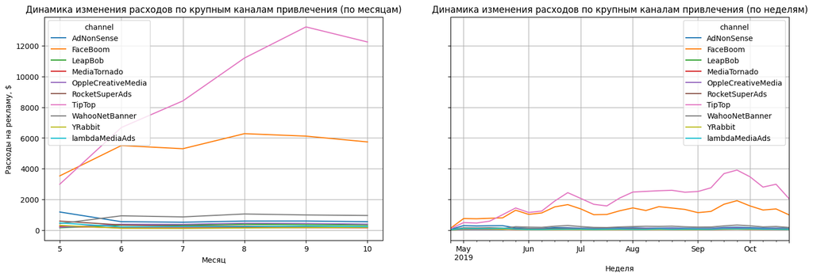

```python
#создаем дополнительные столбцы с месяцем и неделей траты.
cost_dt = costs
cost_dt['month'] = pd.to_datetime(cost_dt['dt']).dt.month
cost_dt['week'] = cost_dt['dt'].astype('datetime64[W]')

#строим графики динамики ищменения расходов по месяцами и по неделям
plt.figure(figsize=(18, 12))

ax1 = plt.subplot(2, 2, 1)
(
    cost_dt
    .pivot_table(index='month', columns='channel', values='costs', aggfunc='sum')
    .plot(grid=True, ax=ax1)
)
plt.ylabel('Расходы на рекламу, $')
plt.xlabel('Месяц')
plt.title('Динамика изменения расходов по крупным каналам привлечения (по месяцам)')

ax2 = plt.subplot(2, 2, 2, sharey = ax1)
(
    cost_dt
    .pivot_table(index='week', columns='channel', values='costs', aggfunc='sum')
    .plot(grid=True, ax=ax2)
)
plt.ylabel('Расходы на рекламу, $')
plt.xlabel('Неделя')
plt.title('Динамика изменения расходов по крупным каналам привлечения (по неделям)')
plt.show()
```

- Выделяются два канала TipTop и FaceBoom, и так большие расходы которых растут со временем, пиковые значения наблюдаются в сентябре.
- Расходы на остальные каналы привлечения не так заметно меняются со временем.

### Средняя стоимость привлечения одного пользователя из каждого источника

```python
profiles.head()
```

|  | user_id | first_ts | channel | device | region | dt | month | payer | acquisition_cost |
| --- | --- | --- | --- | --- | --- | --- | --- | --- | --- |
| 0 | 599326 | 2019-05-07 20:58:57 | FaceBoom | Mac | United States | 2019-05-07 | 2019-05-01 | True | 1.088172 |
| 1 | 4919697 | 2019-07-09 12:46:07 | FaceBoom | iPhone | United States | 2019-07-09 | 2019-07-01 | False | 1.107237 |
| 2 | 6085896 | 2019-10-01 09:58:33 | organic | iPhone | France | 2019-10-01 | 2019-10-01 | False | 0.000000 |
| 3 | 22593348 | 2019-08-22 21:35:48 | AdNonSense | PC | Germany | 2019-08-22 | 2019-08-01 | False | 0.988235 |
| 4 | 31989216 | 2019-10-02 00:07:44 | YRabbit | iPhone | United States | 2019-10-02 | 2019-10-01 | False | 0.230769 |

```python
mean_cac = (
            profiles
            .query('channel != "organic"')
            ['acquisition_cost'].mean()
)
print(f'Стредняя стоимость привлечения одного пользователя: {round(mean_cac, 2)}')
```

```
Стредняя стоимость привлечения одного пользователя: 1.13
```

Посчитаем среднюю стоимость привлечения одного пользователя каждого источника:

```python
(
    profiles
    .query('channel != "organic"')
    .pivot_table(index='channel', values='acquisition_cost', aggfunc='mean')
    .sort_values(by='acquisition_cost', ascending=False)
    .rename(columns={'acquisition_cost': 'mean_acquisition_cost'})

)
```

| channel | mean_acquisition_cost |
| --- | --- |
| TipTop | 2.799003 |
| FaceBoom | 1.113286 |
| AdNonSense | 1.008054 |
| lambdaMediaAds | 0.724802 |
| WahooNetBanner | 0.602245 |
| RocketSuperAds | 0.412095 |
| OppleCreativeMedia | 0.250000 |
| YRabbit | 0.218975 |
| MediaTornado | 0.218717 |
| LeapBob | 0.210172 |

- Самая высокая средняя стоимость привлечения одного клиента у канала TipTop - ~ 2.8$ , что в два раза больше, чем общий средний CAC .
- На втором месте FaceBoom - ~ 1.1$

### Выводы

На этом этапе стало понятно, что

```
- ~ 52% рекламного бюджета было потрачено на канал TipTop. Средняя стоимость привлечения одного клиента у канала TipTop - ~ 2.8$

- ~ 31% было потрачено на канал FaceBoom. Средняя стоимость привлечения одного клиента у канала FaceBoom - ~ 1.1$


Данные вызывают вопрос, окупаются ли эти огромные рекламные затраты. Посмотрим.
```

## Оценка окупаемости рекламы

Используя графики LTV, ROI и CAC, проанализируем окупаемость рекламы. Считаем, что на календаре 1 ноября 2019 года, а в бизнес-плане заложено, что пользователи должны окупаться не позднее чем через две недели после привлечения.

- Проанализируем окупаемость рекламы c помощью графиков LTV и ROI, а также графики динамики LTV, CAC и ROI.
- Проверим конверсию пользователей и динамику её изменения. То же самое сделаем с удержанием пользователей. Построим и изучим графики конверсии и удержания.
- Проанализируем окупаемость рекламы с разбивкой по устройствам. Построим графики LTV и ROI, а также графики динамики LTV, CAC и ROI.
- Проанализируем окупаемость рекламы с разбивкой по странам. Построим графики LTV и ROI, а также графики динамики LTV, CAC и ROI.
- Проанализируем окупаемость рекламы с разбивкой по рекламным каналам. Построим графики LTV и ROI, а также графики динамики LTV, CAC и ROI.
- Ответим на такие вопросы:
  - Окупается ли реклама, направленная на привлечение пользователей в целом?
  - Какие устройства, страны и рекламные каналы могут оказывать негативное влияние на окупаемость рекламы?
  - Чем могут быть вызваны проблемы окупаемости?

### Окупаемость рекламы. LTV, ROY, CAC

Для того, чтобы исследовать окупаемость рекламы, определим горизонт и момент анализа.

```python
#задаем горизонт анализа
analysis_horizon = 14
#задаем момент анализа
observation_date = profiles['dt'].max()
#исключаем органических пользователей
prof = profiles.query('channel != "organic"')
```

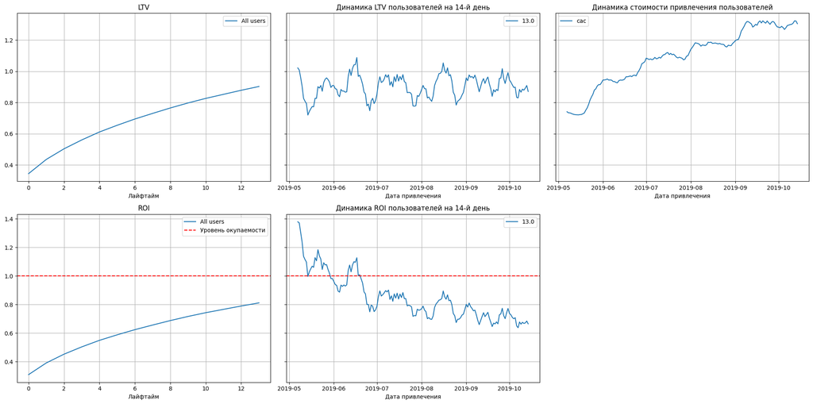

```python
#считаем LTV и ROI
ltv_raw, ltv_grouped, ltv_history, roi_grouped, roi_history = get_ltv(
    prof, orders, observation_date, analysis_horizon
)
#строим графиги LTV , ROI, CAC
plot_ltv_roi(ltv_grouped, ltv_history, roi_grouped, roi_history, analysis_horizon)
```

- Реклама не окупается. ROI в конце второй недели — чуть выше 80%.
- СAC увеличивется, значит и рекламный бюджет растет.
- С конца мая - начала июня клиенты перестают окупаться в двухнедельном лайфтайме.
- LTV достаточно стабилен в двухнедельном лайфтайме.

Чтобы найти причину того, что реклама не окупается, нужно будет посмотреть эти же метрики по всем доступным характеристикам пользователей — стране, каналу привлечения и устройству первого посещения.

### Окупаемость рекламы с разбивкой по устройствам

Посмотрим на показатели окупаемости рекламы:

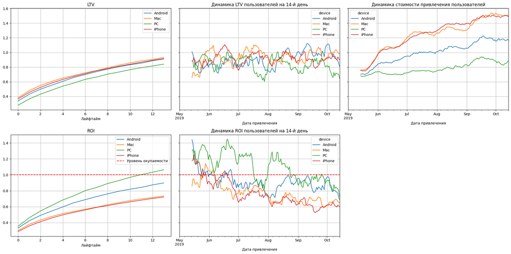

```python
# смотрим окупаемость с разбивкой по устройствам

dimensions = ['device']

ltv_raw, ltv_grouped, ltv_history, roi_grouped, roi_history = get_ltv(
    prof, orders, observation_date, analysis_horizon, dimensions=dimensions
)

plot_ltv_roi(
    ltv_grouped, ltv_history, roi_grouped, roi_history, analysis_horizon, window=14
)
```

1. PC
- LTV и CAC ниже, чем у остальных устройств.
- Пользователеи с PC окупаются на 11 день.
- Так же можно заметить, что в конце августа в двухнедельном лайфтайме пользователи с PC перестают окупаться.
2. Android
- LTV выше, чем у PC, достаточно стабилен в двухнедельном лайфтайме.
- стоимость привлечения пользователей - средняя, относительно других устройств, плавно растет.
- в конце мая в двухнедельном лайфтайме пользователи Android перестают окупаться.
3. MAC iPhone
- имеют примерно одинаковый LTV, который выше остальных
- имеют примерно одинаковый высокий CAC, который увеличивается со временем
- имеют самый низкий ROY, что в конце второй недели реклама окупается лишь на 70%
- так же можно заметить, что в конце мая в двухнедельном лайфтайме пользователи MAC и iPhone перестают окупаться.

Думаю, что это связяно с ростом стоимости привлечения клиентов.

Посмотрим на показатели конверсии и удержания.

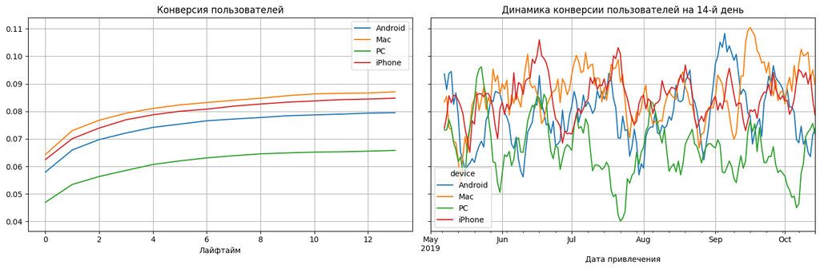

```python
#считаем конверсию с разбивкой по устройствам
conversion_raw, conversion_grouped, conversion_history = get_conversion(
    prof, orders, observation_date, analysis_horizon, dimensions=dimensions)
#строим графики конверсии
plot_conversion(conversion_grouped, conversion_history, analysis_horizon)
```

- Конверсия пользователей MAC и iPhone немного выше остальных.
- Конверсия пользователей PC самая низкая.

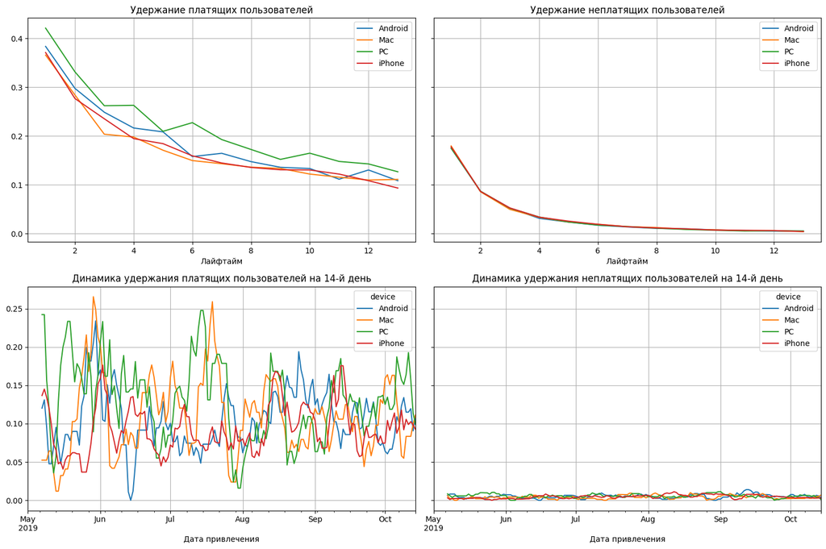

```python
#считаем удержание с разбивкой по устройствам
retention_raw, retention_grouped, retention_history = get_retention(
    prof, visits, observation_date, analysis_horizon, dimensions=dimensions)

#строим графики
plot_retention(retention_grouped, retention_history, analysis_horizon)
```

Пользователи PC удерживаются немного лучше остальных.

**Вывод:**

- Конверсия пользователей PC немного ниже остальных.
- Удержание довольно неплохое для пользователей всех устройств.
- за 14 дней окупаются только пользователи PC.
- Динамика ROY говорит о том, что клиенты Android, MAC и Iphone перестали окупаться в конце Мая, а пользователи PC в конце Августа.

!Неокупаемость может быть связана с ростом стоимости привлечения клиентов. В особенности для MAC и Iphone CAC быстро растет.

### Окупаемость рекламы с разбивкой по странам

Проанализируем окупаемость рекламы с разбивкой по странам.

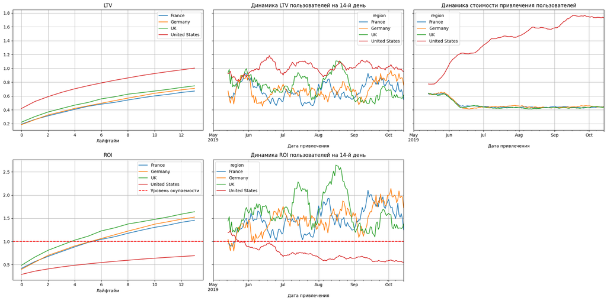

```python
# смотрим окупаемость с разбивкой по странам

dimensions = ['region']

ltv_raw, ltv_grouped, ltv_history, roi_grouped, roi_history = get_ltv(
    prof, orders, observation_date, analysis_horizon, dimensions=dimensions
)

plot_ltv_roi(
    ltv_grouped, ltv_history, roi_grouped, roi_history, analysis_horizon, window=14
)
```

- Пользователи из Франции, Германии и Великобритании стабильно окупаются, а пользователи из США - нет.
- При этом показатель LTV выше для пользователей США
- В динамике двухнедельного лайфтайма пользователи из США перестают окупаться в конце мая. Показатель ROI для этой страны падает с каждым месяцем.
- Как раз в конце мая САС для пользователей из США стал сильно увеличиваться. Стоимость привлечения клиентов из других стран в это время уменьшилась и стабилизировалась.

**Скорее всего неокупаемость пользователей из США связана с сильным ростом стоимости привлечения пользователей.**

Посмотрим на показатели конверсии и удержания пользователей в разбивке по странам:

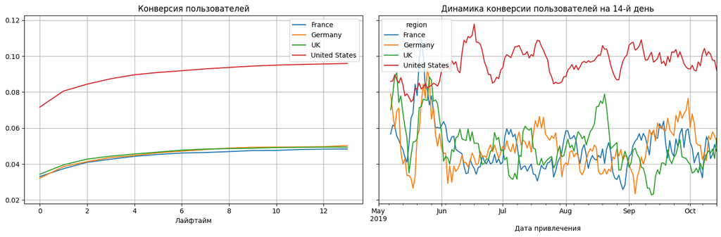

```python
#считаем конверсию с разбивкой по странам
conversion_raw, conversion_grouped, conversion_history = get_conversion(
    prof, orders, observation_date, analysis_horizon, dimensions=dimensions)
#строим графики конверсии
plot_conversion(conversion_grouped, conversion_history, analysis_horizon)
```

Судя по графикам, пользователи из США конвертируются очень хорошо, причём постоянно. Видимо, дело в удержании.

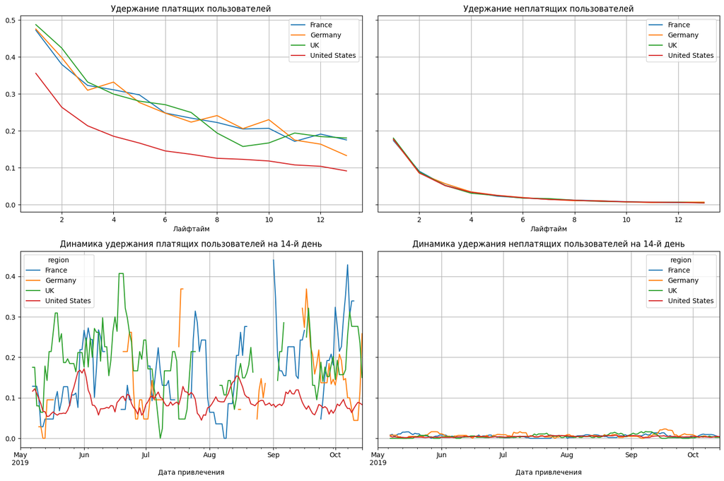

```python
#считаем удержание с разбивкой по странам
retention_raw, retention_grouped, retention_history = get_retention(
    prof, visits, observation_date, analysis_horizon, dimensions=dimensions)

#строим графики
plot_retention(retention_grouped, retention_history, analysis_horizon)
```

**Вывод:**

**Можно сделать вывод, что реклама для США нерентабельна из-за сильного увеличения стоимости привлечения клиентов в конце мая. Она несоразмерна стоимости привлечения клиентов из других стран.**

### Окупаемость рекламы с разбивкой по рекламным каналам

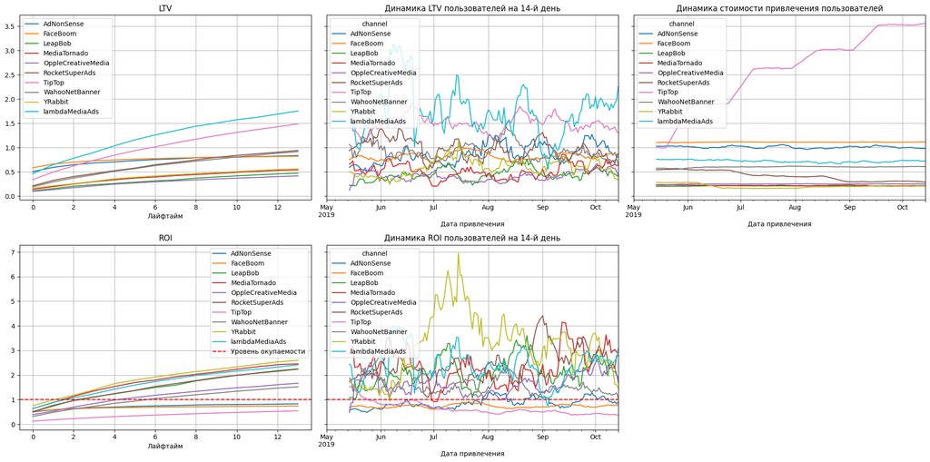

```python
# смотрим окупаемость с разбивкой по рекламным каналам

dimensions = ['channel']

ltv_raw, ltv_grouped, ltv_history, roi_grouped, roi_history = get_ltv(
    prof, orders, observation_date, analysis_horizon, dimensions=dimensions
)

plot_ltv_roi(
    ltv_grouped, ltv_history, roi_grouped, roi_history, analysis_horizon, window=14
)
```

- самые высокие показатели LTV у каналов lambdaMediaAds и ТipTop.
- при этом у канала ТipTop начиная с конца мая стоимость привлеченя клиентов серьезно увеличивается каждый месяц.
- для остальных каналов CAC достаточно стабилен.
- Окупается реклама по всем каналам кроме AdNonSense, FaceBoom и ТipTop.
- В динамике двухнедельного лайфтайма особенно выделяется неокупаемость FaceBoom и ТipTop. ТipTop перестал окупаться в конце мая.

Вывод: Реклама на каналы FaceBoom и ТipTop, на которые тратится больше 80% рекламного бюджета, не окупаются. Хорошие показатели по окупаемости показывают каналы lambdaMediaAds, YRabbit, MediaTornado, RocketSuperAds.

Посотрим на конверсию и удержание:

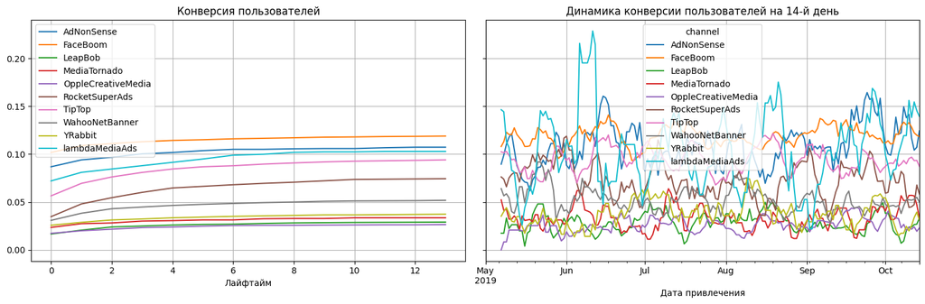

```python
#считаем конверсию с разбивкой по каналам
conversion_raw, conversion_grouped, conversion_history = get_conversion(
    prof, orders, observation_date, analysis_horizon, dimensions=dimensions)
#строим графики конверсии
plot_conversion(conversion_grouped, conversion_history, analysis_horizon)
```

Лучшая конверсия у пользователей, привлеченных с помощью каналов: FaceBoom, AdNonSence, lambdaMediaAds, TitTop, RocketSuperAdsm.

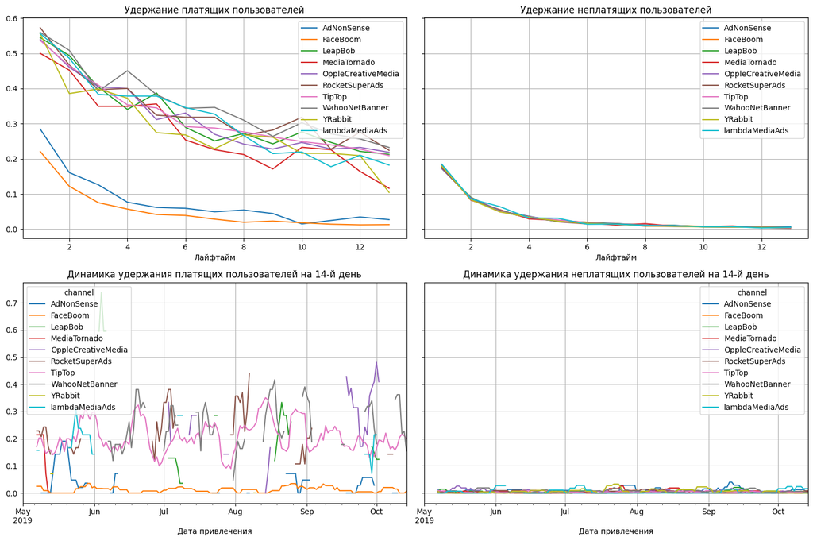

```python
#считаем удержание с разбивкой по каналам
retention_raw, retention_grouped, retention_history = get_retention(
    prof, visits, observation_date, analysis_horizon, dimensions=dimensions)

#строим графики
plot_retention(retention_grouped, retention_history, analysis_horizon)
```

- выделяются низкие показатели удержания пользователей, привлеченных каналами AdNonSense и FaceBoom.

**Вывод:**

Реклама на каналы FaceBoom и ТipTop, на которые тратится больше 80% рекламного бюджета, не окупаются, так как:

- у канала ТipTop начиная с конца мая стоимость привлеченя клиентов серьезно увеличивается каждый месяц.
- выделяются низкие показатели удержания пользователей, привлеченных каналам FaceBoom. Так же нерентабельна реклама на канале AdNonSense, удержание пользователей, привлеченных этим каналом мало.

Могу отметить каналы lambdaMediaAds и RocketSuperAds, они имеют хорошие показатели конверсии и окупаемости.

### Выводы

1. Окупаемость рекламы с разбивкой по устройствам
- Конверсия пользователей PC немного ниже остальных.
- Удержание довольно неплохое для пользователей всех устройств.
- за 14 дней окупаются только пользователи PC.
- Динамика ROY говорит о том, что клиенты Android, MAC и Iphone перестали окупаться в конце Мая, а пользователи PC в конце Августа.

**Неокупаемость может быть связана с ростом стоимости привлечения клиентов. В особенности для MAC и Iphone CAC быстро растет.**

**Реклама для США нерентабельна из-за сильного увеличения стоимости привлечения клиентов в конце мая. Она несоразмерна стоимости привлечения клиентов из других стран.**

3. Окупаемость рекламы с разбивкой по каналам

**Реклама на каналы FaceBoom и ТipTop, на которые тратится больше 80% рекламного бюджета, не окупаются**, так как:

- у канала ТipTop начиная с конца мая стоимость привлеченя клиентов серьезно увеличивается каждый месяц.
- выделяются низкие показатели удержания пользователей, привлеченных каналам FaceBoom. Так же нерентабельна реклама на канале AdNonSense, удержание пользователей, привлеченных этим каналом мало.

**Могу отметить каналы lambdaMediaAds и RocketSuperAds, они имеют хорошие показатели конверсии и окупаемости.**

## Связь рекламных каналов и регионов

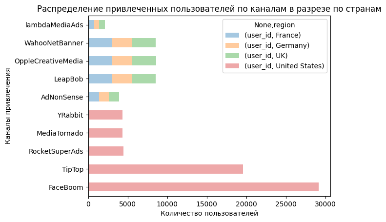

```python
 (
     profiles
     .query('channel != "organic"')
     .pivot_table(index='channel',
                  columns='region',
                  aggfunc={'user_id': 'count'}
                 )
     .sort_values(by=('user_id', 'United States'),
                  ascending=False)
 ).plot(kind='barh', stacked=True, alpha=0.4)

plt.xlabel('Количество пользователей')
plt.ylabel('Каналы привлечения')
plt.title('Распределение привлеченных пользователей по каналам в разрезе по странам')
plt.show()
```

Видно, что каналы разделены по регионам. Есть чисто европейские каналы, а есть каналы, работающие только на США.

- Пользователи, привлеченные в приложение из каналов FaceBoom и ТipTop - все из США.
- Чтобы реабилитироваться в окупаемости рекламы в США можно использовать более выгодный канал - RocketSuperAdsm. Он имеет хорошие показатели окупаемости и конверсии.
- А для Европейских пользователей лучше предпочесть перспективный канал lambdaMediaAds неокупающемуся каналу с низким удержанием AdNonSense.

## Общий вывод

- Выделим причины неэффективности привлечения пользователей.
- Сформулируем рекомендации для отдела маркетинга.

**Развлекательное приложение Procrastinate Pro+ последние несколько месяцев терпит убытки, несмотря на огромные вложения в рекламу.**

Мне были предоставлены данные о пользователях, привлечённых с 1 мая по 27 октября 2019 года:

- лог сервера с данными об их посещениях,
- выгрузка их покупок за этот период,
- рекламные расходы.

Моей задачей было разобраться в причинах и помочь компании выйти в плюс.

**При загрузке и предобработке данных:**

- не было обнаружено пропущенных значений
- не было обнаружено явных дубликатов
- были обнаружены и приведены к snake_case некорректные названия столбцов.
- были найдены и изменены на datetime некорректные типы данных значений в столбцах с датой и временем.

**В ходе анализа данных были найдены определенные закономерности:**

1. Страны и пользователи:
- Больше всего пользователей приходит в приложение из США (100002 человек).
- Так же на США приходится больше всего платящих пользователей (~7% от всех пользователей из США - платящие).
2. Девайсы и пользователи:
- Среди пользователей приложения самый популярный девыйс - iPhone.
- Платящих клиентов больше среди пользователей IOS: Mac (~ 6.3% платащих) и iPhone (~ 6.2% платящих).
3. Каналы привлечения и пользователи:
- Больше всего платящих клиентов было привлечено из канала FaceBoom (3557 - это целых 12% от всех пользователей, привлеченных из этого канала).
- На втором месте по платящим пользователям канал ТipTop.
- На третьем месте - органические пользователи. Больше всего пользуются приложением органические пользователи, правда их доля конверсии довольно низкая.

**Было выяснено, что**

- ~ 52% рекламного бюджета было потрачено на канал TipTop. Средняя стоимость привлечения одного клиента у канала TipTop - ~ 2.8$
- ~31% было потрачено на канал FaceBoom. Средняя стоимость привлечения одного клиента у канала FaceBoom - ~ 1.1$

**И наконец, была проведена оценка окупаемости рекламы:**

1. Окупаемость рекламы с разбивкой по устройствам
- Конверсия пользователей PC немного ниже остальных.
- Удержание довольно неплохое для пользователей всех устройств.
- за 14 дней окупаются только пользователи PC.
- Динамика ROY говорит о том, что клиенты Android, MAC и Iphone перестали окупаться в конце Мая, а пользователи PC в конце Августа.

Неокупаемость может быть связана с ростом стоимости привлечения клиентов. В особенности для MAC и Iphone CAC быстро растет.

Реклама для США нерентабельна из-за сильного увеличения стоимости привлечения клиентов в конце мая. Она несоразмерна стоимости привлечения клиентов из других стран.

3. Окупаемость рекламы с разбивкой по каналам

Реклама на каналы FaceBoom и ТipTop, на которые тратится больше 80% рекламного бюджета, не окупаются, так как:

- у канала ТipTop начиная с конца мая стоимость привлеченя клиентов серьезно увеличивается каждый месяц.
- выделяются низкие показатели удержания пользователей, привлеченных каналам FaceBoom. Так же нерентабельна реклама на канале AdNonSense, удержание пользователей, привлеченных этим каналом мало.

Могу отметить каналы lambdaMediaAds и RocketSuperAds, они имеют хорошие показатели конверсии и окупаемости.

**Рекомендации для отдела маркетинга**

Подавляющее большинство пользователей приходит в приложение из США. Мной были выявлены закономерности, что каналы привлечения имеют специализацию по странам.

Реклама на каналах FaceBoom и ТipTop, на которую ушло больше 80% рекламного бюджета, не окупается, так как:

- у канала ТipTop начиная с конца мая стоимость привлечения клиентов серьезно увеличивается каждый месяц. (Она выросла более, чем в 3 раза за 5 месяцев)
- выделяются низкие показатели удержания пользователей, привлеченных каналом FaceBoom.

Советую разобраться, с чем связан такой рост САС для канала TipTop. Но с такой стоимостью привлечения новых клиентов сотрудничество с этим каналом несет только убытки. А низкие показатели удержания канала FaceBoom наталкивают на мысль, что аудитории этого канала не очень интересен продукт.

Могу предложить достойную альтернативу в США - канал RocketSuperAds.

- пользователи, привлеченные с помощью этого канала хорошо удерживаются
- у этого канала хорошие показатели конверсии.
- реклама на RocketSuperAds отлично окупается в двухнедельном лайфтайме.
- Стоимость привлечения новых пользователей за 4 месяца уменьшилась в два раза.

Что касается Европы, так это убытки, принесенные рекламой на канале AdNonSense. Дело в том, что

- реклама на этом канале не окупается.
- пользователи, привлеченные каналом AdNonSense плохо удерживаются.

Поэтому предлагаю сделать упор на перспективный канал lambdaMediaAds:

- реклама на lambdaMediaAds хорошо окупается.
- этот канал имеет хорошие показатели конверсии и удержания пользователей.

**Вернуться к началу проекта**